# Hazards on the Causal Path

Three Ways to Say ‘Because’ in Survival Analysis

Nathaniel Forde

Data Science @ Personio

and Open Source Contributor @ PyMC

2026-06-14

## Preliminaries

**Who am I?**

- I’m a **data scientist** at **Personio**
  - Bayesian statistician,
  - Reformed philosopher and logician.
- Website: https://nathanielf.github.io/

[figure not shown]

Link to my website

**Code or it didn’t Happen**

The full worked example can be found on my [blog](https://nathanielf.github.io/posts/post-with-code/AalenDynamicPaths/aalen_dynamic_paths.html)

## The Pitch

There are conflicting views of causation and the conflict matters for **mediation analysis** in survival contexts.

- **Counterfactual view** a causal claim is about probabilistic dependence under intervention
- **Process view** a causal claim is about the unfolding of influence over time.

Both are intuitive, but they diverge on mediation cases. This talk builds a **Bayesian dynamic path analysis** in `PyMC` that bridges both views.

## Agenda

**Act I — The puzzle:** Competing causes, competing risks, and why mediation splits the schools

**Act II — The model:** A hybrid Bayesian DPA: Pearl’s structural equations + Aalen’s time-varying mechanisms

**Act III — The lesson:** The lens, not just the answer. Why the trajectory is primary — and what it costs to go beyond it.

# Act I: Three Ways to Say “Because”

## The Counterfactual Test

The two dominant frameworks in causal inference — potential outcomes and do-calculus — share a common foundation:

**“X caused Y”** means **Y would not have occurred without X.**

- Potential outcomes: $\text{ATE} = E[Y(1)] - E[Y(0)]$ — the difference between what happens and what *would have* happened.
- Do-calculus: $E[Y \mid do(X=1)] - E[Y \mid do(X=0)]$ — same logic, structural implementation.

Counterfactual difference-making is the **shared engine** of modern causal inference. Enormously powerful for **total effects**.

But what about **decomposing** effects by pathway? That’s where the test starts to strain.

## Competing Causes

### The Pre-emption Puzzle

Two latent afflictions. Condition A stresses the heart. Condition B affects the lungs.

- A progresses to heart failure first. B never gets the chance. The patient dies.
- **Counterfactual test:** “Would the patient have survived if Condition A hadn’t developed?”
  - No — B would have caused death regardless. So A **fails** the naive counterfactual test for being the cause.
- Yet A is what did the work. The endpoint counterfactual misses **which process was operative**.

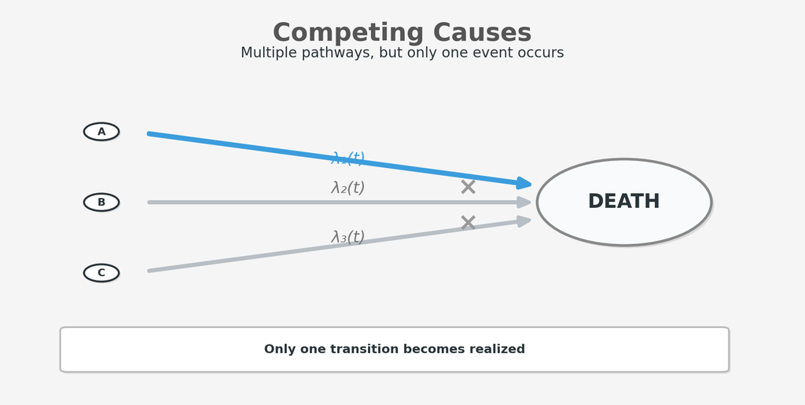

This is a granularity question. At what fidelity do we locate causes?

## From Competing Risks to Mediation

- The competing causes structure is a **competing risks** problem
- Mediation is a similar structure.
  - A treatment works through **multiple channels**.
  - The challenge is understanding the **relative contribution** of each channel to the total effect.
- Attributing credit requires **process decomposition**

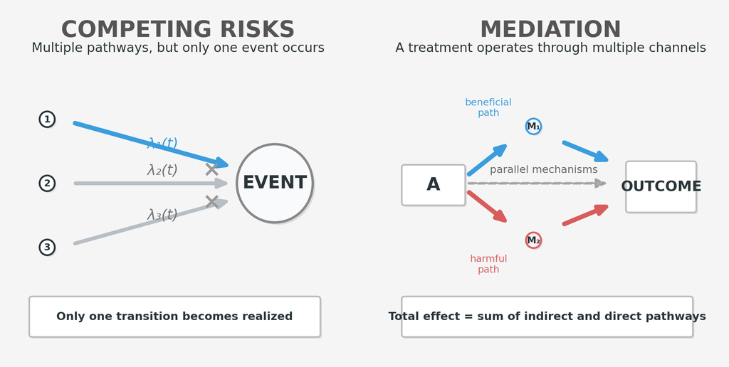

The three schools of causal inference give three different answers — each depending on where they locate causation.

## Three Views of Primacy

Each school answers *“where does causation live?”* differently — and that answer dictates how each handles mediation.

- **Potential Outcomes** — *primacy of intervention.* Rubin, Holland (1986): “no causation without manipulation.” A causal claim must map to an experiment you could run. NDE requires $Y(1, M(0))$ — two simultaneous contrary interventions, no single experiment can implement it. **Mediation has no operational meaning.**
- **Structural Causal Models** — *primacy of equations.* Pearl (2001): causation lives in the stability of structural relations under intervention. Cross-world counterfactuals are computations over the model. **Mediation is first-class — if your equations are right.**
- **Process / Aalen** — *primacy of the trajectory.* Causation is the unfolding of influence in time. Effects are increments to risk; the causal story is told by the path, not the endpoint. **Mediation is decomposed algebraically — no cross-world counterfactual ever arises.**

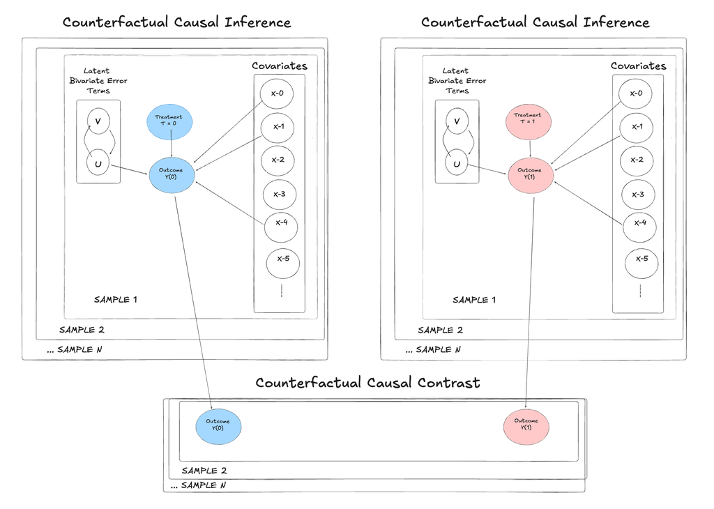

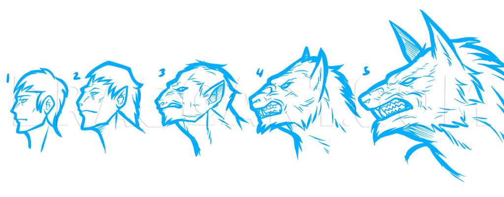

In causal inference and judicial sentencing it matters if you were killed by a man or a werewolf

The process view doesn’t just sidestep the cross-world problem — it **diagnoses** it. The micro lens isn’t a stricter version of the macro lens. It’s looking for causation in the wrong place.

## Perspectives on Mediation

|  | Potential Outcomes | Pearl SCM | Process (Aalen) |
| --- | --- | --- | --- |
| Cause is… | Difference between worlds | Structural mechanism | Unfolding process |
| Mediation? | Ill-defined (cross-world) | Well-defined (structural eqns) | Naturally decomposable |
| Strength | Clean identification | Full causal calculus | Temporal dynamics |
| Weakness | No mediation | Untestable structural assumptions | OLS estimator and non-generative inference |
| Granularity | Endpoint | Each equation / node | Trajectory (cumulative) |

**What if one model could make the mechanism transparent *and* deliver both kinds of estimand?**

## Concrete Mediation Example

### Replicating `dpasurv`

- A patient starts an exercise programme.
- It reduces cardiovascular risk directly. Good.
- But it also causes joint inflammation. The inflammation increases risk over time.
- At the six-month endpoint, the treatment looks modestly protective.
- **You have no idea it’s being undermined.**

To act on this, you need both answers: **which process** is doing the undermining, and **how much** benefit is being lost.

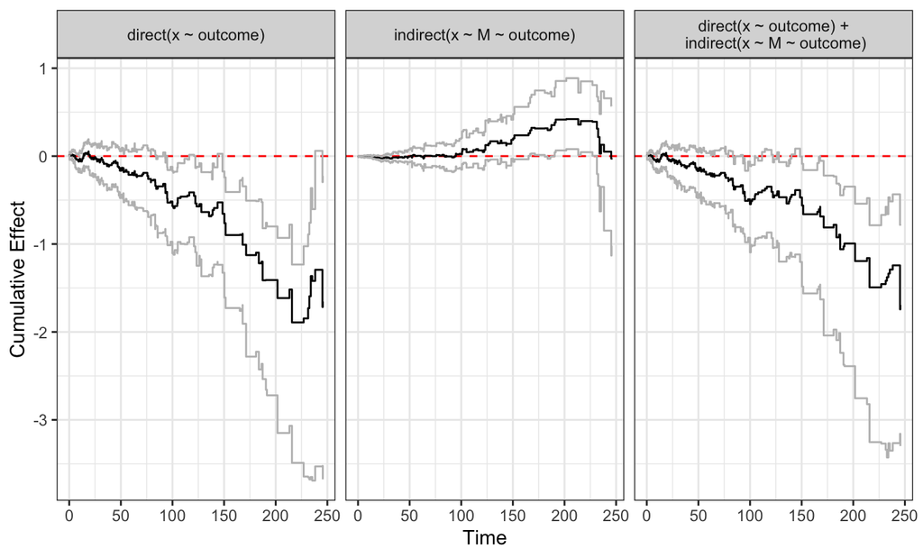

The `dpasurv` benchmark example of mediation structures. We will replicate this example in PyMC

## The Structure: A Sequence of DAGs

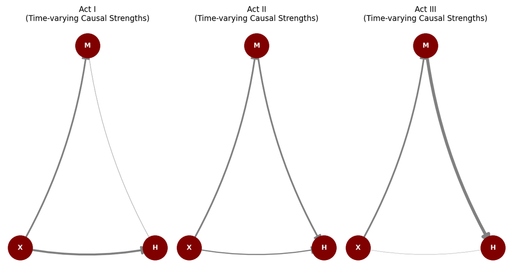

The arrows don’t just exist. They **strengthen and weaken** over time.

**Identification assumption: sequential unconfoundedness**

At each time point, conditional on observed history, there are no unmeasured common causes of treatment, mediator, and hazard. The DAG justifies the path decomposition; this assumption justifies calling it **causal**. In practice violations might occur but as long as they are not systematic, the decomposition can still be useful for understanding the process.

# Act II: Building the Process Model

## Why a Generative Model?

Generative AI has made one idea mainstream: **a model that can sample is a model that can reason about what might have been**.

The same logic applies here. The process view demands a model that **generates trajectories** — not just estimates coefficients.

- A partial likelihood (Cox) conditions out time. **Time is in the residual.**
- A full Poisson likelihood puts time back in: explicit baseline hazard, time-varying coefficients, and the ability to **simulate counterfactual worlds**.

Three technical moves make this possible: **discretise, smooth, bridge.**

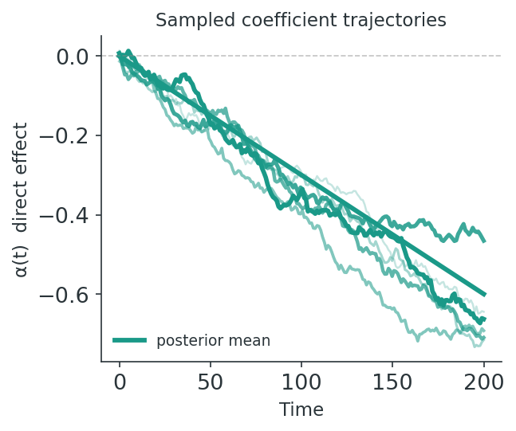

## Discretise + Smooth

**Discretise time into bins**

```python
# Each row: who was at risk, how long, what happened
df["dt"] = df["stop"] - df["start"]
bin_idx = df["bin_idx"].values
```

**Smooth with B-splines**

```python
# Random walk prior on spline coefficients
beta_raw = pm.Normal("beta_raw", 0, 1,
                     dims=('splines', 'tv'))
coef_alpha = pt.cumsum(beta_raw * sigma_smooth,
                       axis=0)
alpha_1_t = pt.dot(basis, coef_alpha[:, 1])
```

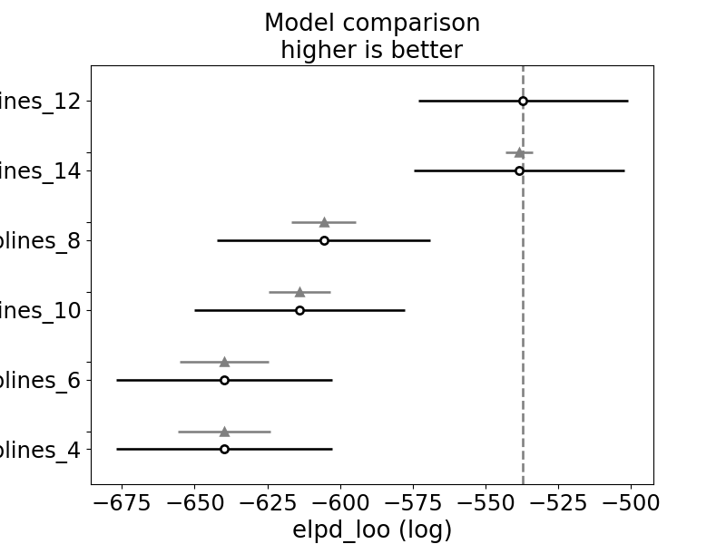

Smoothing splines chosen by LOO cross-validation

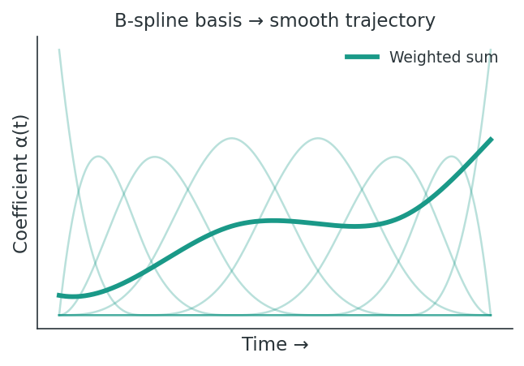

B-spline basis functions and a weighted sum forming a smooth trajectory

## The Poisson Bridge

Once time is discrete, binary events become **counts capped at 1** — and counts have a natural likelihood.

$$d_{it} \sim \text{Poisson}(\lambda(t)), \quad \lambda(t) = Y_{it} \cdot \Delta t \cdot f(\text{linear predictor})$$

The baseline hazard becomes an **explicit parameter**, not a nuisance to be conditioned away.

This is what makes the model **generative**. We can sample from it. We can intervene on it.

We draw our sample trajectories on causal pathways with time-varying coefficients indexed to each temporal stage.

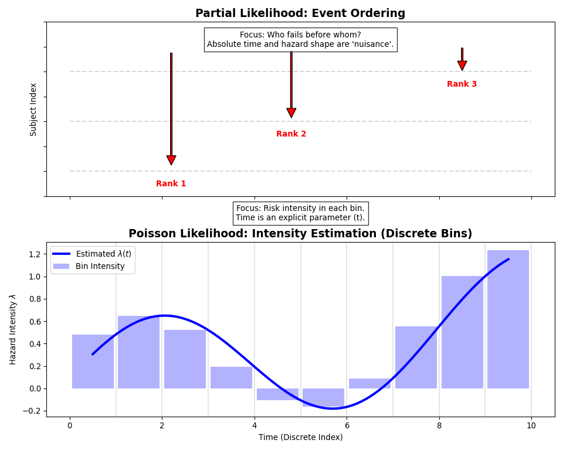

## The Joint Model

**Mediator equation:**

$$M_t = \beta(t) \cdot X + \rho \cdot M_{t-1} + \epsilon$$

The mediator has inertia. Its dynamics are modelled, not assumed away.

**Hazard equation:**

$$\lambda(t) = f\big(\alpha_0(t) + \alpha_1(t) X + \alpha_2(t) M_{t-1}\big)$$

Direct and indirect paths, both time-varying.

These are estimated **simultaneously**. One likelihood, one posterior.

- This is a **hybrid**: structural equations in Pearl’s sense, time-varying mechanisms in Aalen’s sense. PyMC is the substrate that makes both cohabit — the probabilistic programming framework estimates the structure, tracks the process, and propagates uncertainty through both.

## The Model in Code

```python
with pm.Model() as model:
    # 1. Time-varying coefficients via random-walk splines
    beta_raw = pm.Normal("beta_raw", 0, 1,
                        dims=('splines', 'tv'))
    coef_alpha = pt.cumsum(beta_raw * sigma_smooth, axis=0)

    # 2. Mediator equation  (Pearl's X → M, Aalen's β(t))
    mu_m = beta_t[b] * trt + rho * med_lag
    pm.Normal("obs_m", mu=mu_m, sigma=sigma_m,
            observed=med)



    # 3. Hazard equation  (Pearl's X → Y + M → Y, Aalen's α(t))
    eta = (alpha_0_t[b]
        + alpha_1_t[b] * trt        # direct path
        + alpha_2_t[b] * med_lag)   # mediated path

    # 4. Softplus link → Poisson likelihood
    Lambda = dt * pm.math.log1pexp(eta)
    pm.Poisson("obs_event", mu=Lambda,
            observed=events)

    # 5. Path decomposition — falls out of the structure
    pm.Deterministic("direct",   alpha_1_t)
    pm.Deterministic("indirect", beta_t * alpha_2_t)
    pm.Deterministic("total",    alpha_1_t + beta_t * alpha_2_t)

    # 6. One call estimates everything jointly
    idata = pm.sample(draws=2000, tune=2000,
                    nuts_sampler="numpyro")
```

## Direct and Indirect Effects

### (Latent Additive Scale)

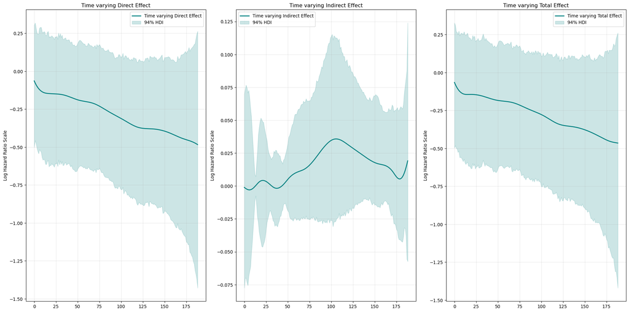

Left: direct effect over time reproduces the data. Middle: indirect effect. Right: Total Effect

## G-Computation for the Marginal Contrasts

```python
# World 1: everyone treated
pm.set_data({'trt': np.ones(n)})
idata_trt1 = pm.sample_posterior_predictive(
    idata, var_names=['Lambda', 'obs_m', 'obs_event'])

# World 0: nobody treated
pm.set_data({'trt': np.zeros(n)})
idata_trt0 = pm.sample_posterior_predictive(
    idata, var_names=['Lambda', 'obs_m', 'obs_event'])
```

We use posterior predictive sampling to generate two counterfactual worlds. Same population. Same model.

The mediator **evolves naturally** under each intervention and we can derive time-varying hazards and survival curves for both.

## Translating to Hazards

### (Observed Scale)

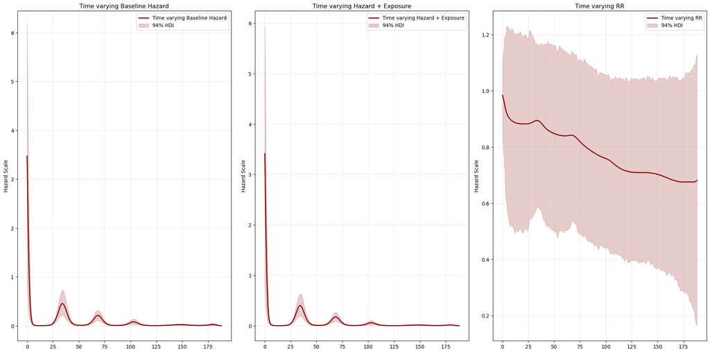

Here we show the hazards propagated under different interventions, and we compare the hazards to get at the relative risk estimand

## The Dual Output

Two independent axes — **estimand** (what are you asking?) and **lens** (where do you locate causation?):

|  | **Macro lens** (realised process) | **Micro lens** (point-wise modularity) |
| --- | --- | --- |
| **Shape** *(which path)* | ✓ trajectory coefficients | ✗ category error — pre-emption shows the cause is the process, not a point-wise modular fact |
| **Size** *(how much)* | — needs structural commitment to size | g-computation, NDE/NIE |

The diagonals carry the work. **Shape lives at the macro lens — and only there.** Size *can* be computed at the micro lens, but only because we accept structural commitments as a price — not because the micro lens is the right home for causal claims.

**The asymmetry**

The macro lens is **primary**. The micro lens earns its keep only when there’s a process already identified to be sized. G-computation is parasitic on the trajectory, not equipotent with it.

# Act III: What the Model Teaches Us

## Hickam’s Dictum for Causal Paths

**Ockham’s Razor** says: one cause, one effect, pare it down.

- An endpoint analysis applies Ockham to the treatment: **17% risk reduction. Done.**

**Hickam’s Dictum** says: *“A patient can have as many diseases as they damn well please.”*

- If treatment operates through **multiple channels simultaneously** collapsing them is oversimplification.

Refusing to decompose isn’t caution, it’s a commitment. It assumes all paths point the same way. When they don’t, **aggressive simplification is misspecification from the start**

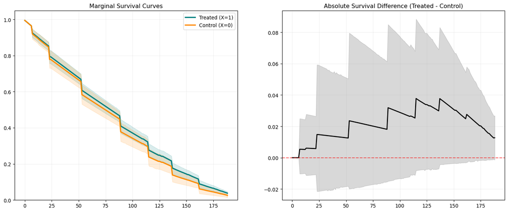

## Cross-World Independence

**The assumption that makes mediation fragile:**

$$Y(1, M(0)) \perp\!\!\!\perp M(1) \mid X$$

*“The M → Y relationship under treatment is the same as it would be if M had been generated under control.”*

- Untestable from data
- Often implausible — treatment frequently changes the *meaning* of M

The trajectory decomposition trades one assumption for another: **additive structural form** instead of cross-world counterfactual independence.

**Trajectory decomposition**

$$\text{total}(t) = \alpha_1(t) + \beta(t)\alpha_2(t)$$

Algebraic identity, not counterfactual subtraction. Identified by *sequential within-world unconfoundedness* + **additive structural form**. A parametric commitment, but one the data can speak to directly.

**G-computation NDE**

Plug $M(0)$ trajectory into hazard under $X=1$.

This **is** a cross-world counterfactual. Pays the full identification price. The price buys you a magnitude.

## NDE and the Hidden Harm

The trajectory told us *which* path is harmful and *when*. Now we pay the modularity cost to answer: **how much?**

```python
# Mediator trajectories under control
m_nat = idata_trt0.posterior_predictive['obs_m']

# Hazard under treatment, with control mediator
eta_nde = (alpha_0(t) + alpha_1(t) * 1
           + alpha_2(t) * m_nat)

# Transform through the link and simulate
hazard_nde = dt * log1pexp(eta_nde)
```

- Plug one world’s mediator into another world’s hazard — this **is** the cross-world counterfactual, requiring full modularity.
- The price buys you a number you can subtract from the total.

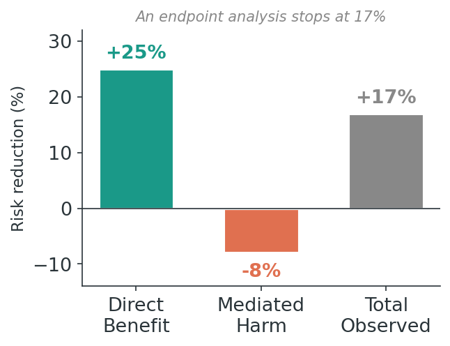

**Implication:** Do not abandon the treatment. Intervene on the mediator after day 100. The NDE is a cross-world comparison — justified by modularity — but it’s what lets you subtract from the total and reveal the hidden structure.

## What We Built

**1.** A hybrid model: Pearl’s structural equations + Aalen’s time-varying mechanisms, unified in PyMC with full posterior uncertainty.

**2.** Two kinds of estimand from one model: **coefficients** for the shape of the mechanism, **g-computation** for the size of the effect — including NDE/NIE.

**3.** Two scales, but not symmetric: the **macro lens** (spline-smoothed trajectories) identifies the realised process and escapes cross-world independence. The **micro lens** (point-wise modularity) sizes what macro has already identified.

**4.** The macro question is the right question; the micro answer sizes what macro identifies. Probabilistic programming is the substrate that makes both answerable — but only one is primary.

## The Lesson

For time-evolving mediation, the trajectory is the right unit of analysis.

- The competing causes structure showed it: ask *“would the outcome have differed at the endpoint?”* and you miss which process was operative. Ask *“which path transmitted the influence, and when?”* and you get an answer you can act on.
- The trajectory coefficients are not a *coarser* estimand than the cross-world NDE. They are the **right estimand for the question**. The NDE is a useful auxiliary — it sizes what the trajectory has already identified.
- The endpoint view isn’t caution, it’s a commitment to the wrong lens. So is point-wise modularity when the question is *which path did the work?*

**Two scales. One primary.**

- **Shape** (estimand) lives at the **macro lens** — and only there. The splines identify the realised process — which path, when, what sign.
- **Size** (estimand) is computed at the **micro lens** via g-computation — but only once the macro lens has identified the process worth sizing.
- **LOO** and **Sensitivity Analysis** test whether your answer depends on the precise model or is robust to violated assumptions.

Probabilistic programming gives us both scales — but they aren’t symmetric. The macro lens is **primary**.

## Practitioner’s Takeaway

[figure not shown]

## Thank You

**Resources**

- Blog post: [nathanielf.github.io](https://nathanielf.github.io/posts/post-with-code/AalenDynamicPaths/aalen_dynamic_paths.html)
- PyMC: pymc.io
- Fosen et al. (2006), “Dynamic path analysis,” *Lifetime Data Analysis*
- Aalen (1989), “A linear regression model for the analysis of life times,” *Statistics in Medicine*
- Holland (1986), “Statistics and Causal Inference,” *JASA*
- Pearl (2001), “Direct and Indirect Effects,” *UAI*
- Robins & Richardson (2010), “Alternative graphical causal models”

[figure not shown]

Coming Soon to a Book Store near you!